# Lab 01 - Hello R!

Due: Tue, Jan 21 at 11:59pm

R is the name of the programming language itself and RStudio is a convenient interface.

This lab will go through much of the same workflow we demonstrated in class this week. The main goal is to reinforce our demo of R and RStudio, which we will be using throughout the course both to learn statistical concepts discussed in the course and to make informed conclusions through real data analysis.

git is a version control system (like “Track Changes” features from Microsoft Word but more powerful) and GitHub is the home for your Git-based projects on the internet (like DropBox but much better)

As the labs progress, you are encouraged to explore beyond what the labs dictate; a willingness to experiment will make you a much better programmer. Before we get to that stage, however, you need to build some basic fluency in R. Today we begin with the fundamental building blocks of R and RStudio: the interface, reading in data, and basic commands.

To make versioning simpler, this is an individual lab. Additionally, we want to make sure everyone gets a significant amount of time at the steering wheel.

Your lab TA will lead you through the Getting Started, Packages, and and Warm up sections.

# Getting Started

Each of your assignments will begin with similar steps below. You saw these once in class, and they’re outlined in detail here again. Going forward each lab will start with a “Getting started” section but details will be a bit more sparse than this. You can always refer back to this lab for a detailed list of the steps involved for getting started with an assignment.

## Clone Assignment Repo

- First, go to the link for the assignment in order to create your personal private repository corresponding to the assignment. This link may be found at https://classroom.github.com/a/tle2iwF6. Accepting the assignment creates a repository similar to lab01-[github_name]

[figure not shown]

[figure not shown]

- Click on the green Clone or download button on that repository, and copy the git URL (it should end in .git)

[figure not shown]

- Go to RStudio Cloud and into the STA 199 course workspace. Create a New Project from Git Repo and copy the git URL from your personal workspace. Make sure “Add packages from the base project” is checked.

[figure not shown]

[figure not shown]

- Click OK, and you should see the contents from your GitHub repo in the `Files` pane in RStudio.

## Configure git

There is one more piece of housekeeping we need to take care of before we get started. Specifically, we need to configure git so that RStudio can communicate with GitHub. This requires two pieces of information: your email address and your name.

To do so, you will use R function `use_git_config()` from package `usethis`.

Type the following lines of code in the **console**, where you use your own name and email address you provided GitHub.

```r
library(usethis)
use_git_config(user.name="your name", user.email="your email")
```

For example, mine would be

```r
library(usethis)
use_git_config(user.name="Shawn Santo", user.email="shawn.santo@duke.edu")
```

# Packages

In this lab we will work with two packages: `datasauRus` which contains the datasets, and `tidyverse` which is a collection of packages for doing data analysis in a “tidy” way.

At any point, you can Knit your document and see the results.

Are both `tidyverse` and `datasauRus` installed? If not, install them in the console (refer to Tuesday’s slides).

```r
library(tidyverse)
library(datasauRus)
```

# Warm up

Before we introduce the data, we’re going to go through our first stage, commit, and push version control cycle.

## Project name:

Currently your project is called *Untitled Project*. Update the name of your project to be “Lab 01 - Hello R” in the header of the RStudio Cloud project.

## YAML:

The top portion of your R Markdown file (between the three dashed lines) is called the YAML. It stands for “YAML Ain’t Markup Language”. It is a human friendly data serialization standard for all programming languages. All you need to know is that this area is called the YAML (we will refer to it as such) and that it contains meta information about your document.

Open the R Markdown (Rmd) file in your project, change the author name to your name, and knit the document.

## Commiting changes:

Now, go to the Git pane in your RStudio instance. This will be in the top right hand corner in a separate tab.

If you have made and saved changes to your Rmd file, you should see it listed here. Click on **Diff**. This shows you the *diff*erence between the last committed state of the document and its current state that includes your changes. If you’re happy with these changes, stage them, and write “Update author name” in the **Commit message** box, then click **Commit**.

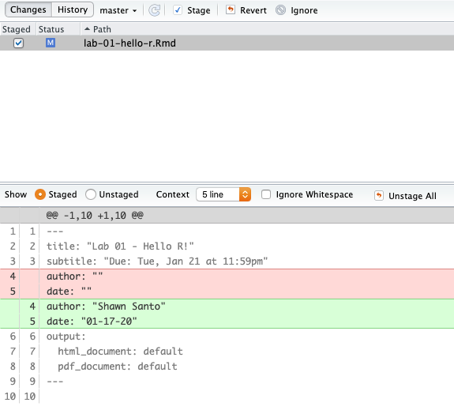

Of course, you don’t have to commit after every change, as this would get quite cumbersome. You should consider committing states that are meaningful to you for inspection, comparison, or restoration. In the first few assignments we will tell you exactly when to commit and in some cases, what commit message to use. As the semester progresses we will let you make these decisions.

## Pushing changes:

Now that you have made an update and committed this change, it’s time to push these changes to the web! Or more specifically, to your repo on GitHub so that others can see your changes. By others, we mean the course teaching team (your repos in this course are private to you and us, only).

In order to push your changes to GitHub, click on **Push**. This will prompt a dialog box where you first need to enter your user name, and then your password. We *will* soon teach you how to save your password so you don’t have to enter it every time.

# Data

If it’s confusing that the data frame is called `datasaurus_dozen` when it contains 13 datasets, you’re not alone! Have you heard of a [baker’s dozen](https://en.wikipedia.org/wiki/Dozen#Baker's_dozen)?

The data frame we will be working with today is called `datasaurus_dozen` and it’s in the `datasauRus` package. Actually, this single data frame contains 13 datasets, designed to show us why data visualization is important and how summary statistics alone can be misleading. The different datasets are marked by the `dataset` variable.

To find out more about the dataset, type the following in your **console**.

```r
?datasaurus_dozen
```

A question mark before the name of an object will always bring up its help file. This command must be run in the **console**.

1. Based on the help file, how many rows and how many columns does `datasaurus_dozen` have? What are the variables included in the data frame? Add your responses to your lab report. When you’re done, commit your changes with the commit message “Added answer for Ex 1”, and push.

Let’s take a look at what these datasets are. To do so we can make a *frequency table* of the dataset variable:

```r
datasaurus_dozen %>%
  count(dataset) %>%
  print(13)
```

```
## # A tibble: 13 x 2
##    dataset        n
##    <chr>      <int>
##  1 away         142
##  2 bullseye     142
##  3 circle       142
##  4 dino         142
##  5 dots         142
##  6 h_lines      142
##  7 high_lines   142
##  8 slant_down   142
##  9 slant_up     142
## 10 star         142
## 11 v_lines      142
## 12 wide_lines   142
## 13 x_shape      142
```

Matejka, Justin, and George Fitzmaurice. “Same stats, different graphs: Generating datasets with varied appearance and identical statistics through simulated annealing.” Proceedings of the 2017 CHI Conference on Human Factors in Computing Systems. ACM, 2017.

The original Datasaurus (`dino`) was created by Alberto Cairo in [this great blog post](http://www.thefunctionalart.com/2016/08/download-datasaurus-never-trust-summary.html). The other Dozen were generated using simulated annealing and the process is described in the paper *Same Stats, Different Graphs: Generating Datasets with* *Varied Appearance and Identical Statistics* through Simulated Annealing by Justin Matejka and George Fitzmaurice. In the paper, the authors simulate a variety of datasets that the same summary statistics to the Datasaurus but have very different distributions.

# Data visualization and summary

2. Plot `y` vs. `x` for the `dino` dataset. Then, calculate the correlation coefficient between `x` and `y` for this dataset.

Below is the code you will need to complete this exercise. Basically, the answer is already given, but you need to include relevant bits in your Rmd document and successfully knit it and view the results.

Start with the `datasaurus_dozen` and pipe it into the `filter()` function to filter for observations where `dataset == "dino"`. Store the resulting filtered data frame as a new data frame called `dino_data`.

```r
dino_data <- datasaurus_dozen %>%
  filter(dataset == "dino")
```

There is a lot going on here, so let’s slow down and unpack it a bit.

First, the pipe operator: `%>%`, takes what comes before it and sends it as the first argument to what comes after it. So here, we’re saying `filter` the `datasaurus_dozen` data frame for observations where `dataset == "dino"`.

Second, the assignment operator: `<-`, assigns the name `dino_data` to the filtered data frame.

Next, we need to visualize these data. We will use the `ggplot()` function for this. Its first argument is the data you’re visualizing. Next we define the `aes`thetic mappings. In other words, the columns of the data that get mapped to certain aesthetic features of the plot, e.g. the `x` axis will represent the variable called `x` and the `y` axis will represent the variable called `y`. Then, we add another layer to this plot where we define which `geom`etric shapes we want to use to represent each observation in the data. In this case we want these to be points, hence `geom_point()`.

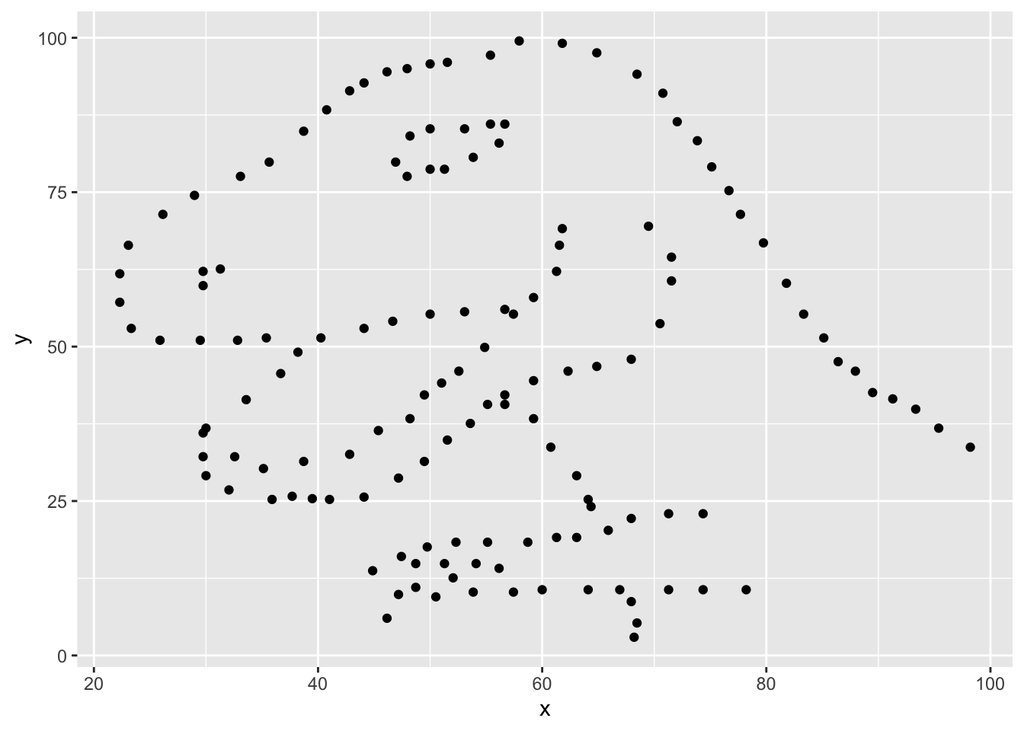

```r
ggplot(data = dino_data, mapping = aes(x = x, y = y)) +
  geom_point()
```

For the second part of this exercises, we need to calculate a summary statistic: the correlation coefficient. Correlation coefficient, often referred to as $r$ in statistics, measures the linear association between two variables. You will see that some of the pairs of variables we plot do not have a linear relationship between them. This is exactly why we want to visualize first: visualize to assess the form of the relationship, and calculate $r$ only if relevant. In this case, calculating a correlation coefficient really doesn’t make sense since the relationship between `x` and `y` is definitely not linear.

For illustrative purposes, let’s calculate correlation coefficient between `x` and `y`.

Start with `dino_data` and calculate a summary statistic that we will call `r` as the `cor`relation between `x` and `y`.

```r
dino_data %>%
  summarize(r = cor(x, y))
```

```
## # A tibble: 1 x 1
##         r
##     <dbl>
## 1 -0.0645
```

*This is a good place to pause, commit changes with the commit message* *“Added answer for Ex 2”, and push.*

3. Plot `y` vs. `x` for the `star` dataset. You can (and should) reuse code we introduced above, just replace the dataset name with the desired dataset. Then, calculate the correlation coefficient between `x` and `y` for this dataset. How does this value compare to the `r` of `dino`?

*This is another good place to pause, commit changes with the commit message* *“Added answer for Ex 3”, and push.*

4. Plot `y` vs. `x` for the `circle` dataset. You can (and should) reuse code we introduced above, just replace the dataset name with the desired dataset. Then, calculate the correlation coefficient between `x` and `y` for this dataset. How does this value compare to the `r` of `dino`?

*You should pause again, commit changes with the commit message* *“Added answer for Ex 4”, and push.*

Facet by the dataset variable, placing the plots in a 3 column grid, and don’t add a legend.

Finally, let’s plot all datasets at once. In order to do this we will make use of faceting.

```r
ggplot(datasaurus_dozen, aes(x = x, y = y, color = dataset))+
  geom_point()+
  facet_wrap(~ dataset, ncol = 3) +
  theme(legend.position = "none")
```

And we can use the `group_by()` function to generate all the summary correlation coefficients.

```r
datasaurus_dozen %>%
  group_by(dataset) %>%
  summarize(r = cor(x, y)) %>%
  print(13)
```

5. Include the faceted plot and summary of the correlation coefficients in your lab write-up. To do this, add code chunks to your Rmd document and give the chunks an appropriate name. Below the code chunks, briefly comment on what you observe about the plots and correlation values. One to two sentences is sufficient.

You’re done with the data analysis exercises, but we’d like to do two more things to customize the look of the report.

## Resize your figures

We can customize the output for a particular R chunk by including chunk options.

6. In the R chunks you wrote for Exercises 2-5, customize the figure output dimensions as specified below.

   For Exercises 2-4, we want square figures. We can use `fig.height` and `fig.width` as chunk options to adjust the height and width of figures. Modify the chunks in Exercises 2-4 as follows:

   ```{r exercise2, fig.height=5, fig.width=5}

   Code that created the figure

   ```

   For Exercise 5, modify your figure to have `fig.height=10` and `fig.width=6`.

   Save and knit.

# Submission

To facilitate and expedite grading in this class, we’ll be submitting .pdf documents to [Gradescope](https://www.gradescope.com/). Once you are satisfied with your lab, Knit to PDF to create a .pdf document. You may notice that the formatting/theme of the report has changed – this is expected.

Once you’ve created this .pdf file, you’re done! Stage and commit all remaining changes, use the commit message “Done with Lab 1!” and push. Before you wrap up the assignment, make sure all documents are updated on your GitHub repo – we will be checking these to make sure you have been practicing how to commit and push changes.

Please only upload your PDF document to [Gradescope](https://www.gradescope.com/). Before you submit the uploaded document, mark where each answer is to the exercises. If any answer spans multiple pages, then mark all pages.